# The impact of injuries on team performance in the NFL

#### NAME: Yonas Mekonnen

##### CMSC320 FALL2020 Section:0201

In a heavy contact sport like American football, injuries to athletes are very common, and when you consider the fact that an NFL roster consists of 53 players the opportunity for injuries becomes even more common. So how do teams deal with injuries? Do injuries make a significant impact on team performance? In this tutorial, I will be using the entire data science pipeline to provide some insights for answering these questions.

## Data selection

Before invesitgating the impact of injuries in the NFL, I need to first gather some data about player injuries in the NFL. Unfortnunately, there was no database or dataset of player injuries that I could get my hands on, so I decided to scrape websites for data.

Pro-football reference is a catalog of statistics regarding NFL teams. The website also contains information regarding injuries. More specifically, the website has a page dedicated for injuries of a team over the course of a season. Each page contains a table which reports which players were reported as injuried, the row entries are players on the roster, and the columns is week opponent. Each player on a roster is reported as either IR, OUT, QUESTIONABLE, DOUBTFUL, (c19 for 2020) or None if not injuried and each are defined as.

### Defintions of column names

IR- the player is on the injured reserve list  
OUT - the player is out  
DOUBTFUL - the player has a 25% chance of playing  
QUESTIONABLE - the player has a 50% chance of playing  
C19 - (only for 2020) the player on covid reserve list  
Definition of the rest of initial columns after data collection:  
record - team win loss ratio  
expected_record - an estimate of what the team's record "should have been"  
total_aval_players - number of players on roster * number of weeks played

Using python I then scrapped the injury data from each page, collecting the injury history of every team for the past 10 years. In addition, to injury history I also captured the record and expected record of each team for 10 years. According to pro-football reference the expected record is "an estimate of what the team's record "should have been," given the team's points scored and allowed." These to metrics will help us quantify a team's performance.

### source and acknowledgment

pro-football reference is a catalog of statistics regarding NFL team. All the data I that scraped were from https://www.pro-football-reference.com

## Data collection

note: running this cell will take 5-10 minutes. It's making about 640 get requests and processing each response.

```python
# Modules used to scrap data
import requests
from bs4 import BeautifulSoup
import re
import pandas as pd

# league years and teams to look-up index for url
years = [2010 + i for i in range(11)]
teams = ['buf','nwe','mia','nyj','clt','oti','htx','jax','pit','cle','rav','cin','kan','rai','den','sdg',
         'was','nyg','phi','dal','nor','tam','atl','car','gnb','chi','min','det','ram','sea','crd','sfo']

data = []

# making a get request for each team in each league year
for year in years:
    for team in teams:

        #the url's with injury and performance data
        url = f"https://www.pro-football-reference.com/teams/{team}/{year}_injuries.htm"
        url2 = f"https://www.pro-football-reference.com/teams/{team}/{year}.htm"

        #making a get request
        r = requests.get(url,headers={"User-Agent":"Chrome/84.0"})
        r2 = requests.get(url2,headers={"User-Agent":"Chrome/84.0"})

        #parsing the html response from server
        root = BeautifulSoup(r.content,"html")
        root2 = BeautifulSoup(r2.content,"html")

        # converting the html to a string to use regular expression to extract
        # record, play-off appearance, and expected record
        s = str(root2)
        pattern = r"\<strong\>Record:\<\/strong\> ([0-9]{1,2}-[0-9]{1,2}-[0-9])"
        record = re.search(pattern,s).group(1)
        pattern = r"Expected W-L\<\/a\>:\<\/strong\> ([0-9]{1,2}.[0-9]{1,2}-[0-9]{1,2}.[0-9]{1,2})"
        expected_record = re.search(pattern,s).group(1)
        pattern = r"\<strong\>Playoffs:\<\/strong\>"
        playoff = re.search(pattern,s)
        playoffs = 1 if playoff else 0

        #finding the table from the other get request and converting to a dataframe
        table = root.find('table')
        df = pd.read_html(str(table))[0]

        total_aval_players = len(df.columns)*len(df)

        #iterating through dataframe and counting the number of injuries for the year
        OUT = 0
        IR = 0
        C19 = 0
        doubtful = 0
        for index,row in df.iterrows():
            for week in df.columns:
                if row[week] == 'IR':
                    IR = IR + 1
                elif row[week] == 'O':
                    OUT = OUT + 1
                elif row[week] == 'D':
                    doubtful = doubtful + 1
                elif row[week] == 'C19':
                    C19 = C19 + 1

        #adding obervation to that dataset
        row = [team,year,OUT,IR,doubtful,C19,(OUT+IR+C19+doubtful),total_aval_players,record,expected_record,playoffs]
        data.append(row)

# making a dataframe with all the scrapped data and labeling columns
col = ['team','year','out','IR','doubtful','C19','total','total_aval_players','record','expected_record','playoffs']
injury_data = pd.DataFrame(data,columns=col)
injury_data.head()
```

|  | team | year | out | IR | doubtful | C19 | total | total_aval_players | record | expected_record | playoffs |
| --- | --- | --- | --- | --- | --- | --- | --- | --- | --- | --- | --- |
| 0 | buf | 2010 | 45 | 104 | 3 | 0 | 152 | 782 | 4-12-0 | 4.4-11.6 | 0 |
| 1 | nwe | 2010 | 50 | 168 | 10 | 0 | 228 | 756 | 14-2-0 | 12.3-3.7 | 1 |
| 2 | mia | 2010 | 32 | 75 | 10 | 0 | 117 | 578 | 7-9-0 | 6.2-9.8 | 0 |
| 3 | nyj | 2010 | 31 | 47 | 4 | 0 | 82 | 740 | 11-5-0 | 9.8-6.2 | 1 |
| 4 | clt | 2010 | 106 | 198 | 7 | 0 | 311 | 972 | 10-6-0 | 9.1-6.9 | 1 |

Since scrapping all that data took a lot of time, we want to make a copy for original reference.

```python
cpy = injury_data.copy(deep=True)
```

## Data processing

After collecting the raw data, we want to process it to gain more insight. First we want to convert the record and expected record to winning percentage and expected winning percent, to normalize team performance across league years. In addition, we also want to compute the ratio of the amount of games each player didn't play due to injury with the amount of games each player could have played if healthy.

```python
dt = cpy.copy()

winning_percentage = []
expected_winning_percentage = []
percent_of_players_lost_to_injury = []

#ierating through each observation and computing new values
for index,row in dt.iterrows():

    #using regular expression to extract record and winning record
    q = re.search(r"([0-9]{1,2})-([0-9]{1,2})-([0-9]{1,2})",row['record'])
    q2 = re.search(r"([0-9]{1,2}.[0-9]{1,2})-([0-9]{1,2}.[0-9]{1,2})",row['expected_record'])
    w = int(q.group(1))
    ew = float(q2.group(1))
    l = int(q.group(2))
    el = float(q2.group(2))
    d = int(q.group(3))

    #calculating percentage
    winning_percentage.append(((w+(d/2))/(w+l+d)))
    expected_winning_percentage.append(ew/(ew+el))
    percent_of_players_lost_to_injury.append(row['total']/row['total_aval_players'])

# adding new columns and removing unused ones
dt['winning_percentage'] = winning_percentage
dt['expected_winning_percentage'] = expected_winning_percentage
dt['percent_of_players_lost_to_injury'] = percent_of_players_lost_to_injury
dt = dt.drop(['total','record','C19','out','IR','doubtful','total_aval_players','expected_record'],axis=1)
dt.head()
```

|  | team | year | playoffs | winning_percentage | expected_winning_percentage | percent_of_players_lost_to_injury |
| --- | --- | --- | --- | --- | --- | --- |
| 0 | buf | 2010 | 0 | 0.2500 | 0.27500 | 0.194373 |
| 1 | nwe | 2010 | 1 | 0.8750 | 0.76875 | 0.301587 |
| 2 | mia | 2010 | 0 | 0.4375 | 0.38750 | 0.202422 |
| 3 | nyj | 2010 | 1 | 0.6875 | 0.61250 | 0.110811 |
| 4 | clt | 2010 | 1 | 0.6250 | 0.56875 | 0.319959 |

Now without any context percent of players lost to injury would not make must sense. One thing we can do is find the league average for each year. This allows us to check if a team is more injuried than the average, which can help us quantify impact of injuries on a team.

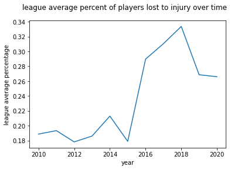

```python
from matplotlib import pyplot

#grouping the data by year and taking the average for each year.
league_year_averages = dt.groupby(['year']).mean()
average_percent_of_players_lost_to_injury = league_year_averages['percent_of_players_lost_to_injury'].values

#adding league average to dataset
league_average_percent_of_players_lost_to_injury = []
for index,row in dt.iterrows():
    league_average_percent_of_players_lost_to_injury.append(
        league_year_averages['percent_of_players_lost_to_injury'][row['year']])
dt['league_average_percent_of_players_lost_to_injury'] = league_average_percent_of_players_lost_to_injury

# plotting the league average over time
years = [ 2010 + i for i in range(11)]
pyplot.plot(years,average_percent_of_players_lost_to_injury)
pyplot.suptitle('league average percent of players lost to injury over time')
pyplot.ylabel('league average percentage')
pyplot.xlabel('year')
pyplot.show()
```

From the plot above we can see that the league average for injuries have been high for the past few seasons compared to the previous seasons. This doesn't tell us much but it a step in the right direction.

## More data processing and data visualization

Now it's reasonable to assume that a team with a bad record would likely be more injured than a team with a good record and vise-versa. So we can use a bar graph to keep a tally and check if there is some truth in our assumption.

```
teams with less than league average injuries: 86,teamswith more than league average injuries: 108
```

[figure not shown]

```
teams with less than league average injuries: 87,teams with more than league average injuries: 71
```

[figure not shown]

```python
#marking if a team has a winning record
winning_record = [1 if row['winning_percentage'] > .5 else 0 for idx,row in dt.iterrows() ]
dt['winning_record']  = winning_record
winningteams = dt.groupby(['winning_record'])

# making a injury_difference which indicates if a teams is more injuried than the league average or not.
dt['inj_diff'] =  dt['percent_of_players_lost_to_injury'] - dt['league_average_percent_of_players_lost_to_injury']

# grouping teams with winning record and losing record and plotting a bar graph to indicate the ratio between
# above and below league average for each teams with winning record and losing record separately.
for group in winningteams:
    if group[0] == 1:
        inj = [1 if row['inj_diff'] <= 0 else 0 for idx,row in group[1].iterrows()]
        print(f"teams with less than league average injuries: {sum(inj)},teams with more than league average injuries: {len(inj)-sum(inj)}")
        pyplot.bar(['below league avearage injuries','above league average injuries'],[sum(inj),len(inj)-sum(inj)])
        pyplot.suptitle("Teams with winning record (2010-2019)")
        pyplot.ylabel("number of teams")
        pyplot.show()
    else:
        inj = [1 if row['inj_diff'] <= 0 else 0 for idx,row in group[1].iterrows()]
        print(f"teams with less than league average injuries: {sum(inj)},teamswith more than league average injuries: {len(inj)-sum(inj)}")
        pyplot.bar(['below league avearage injuries','above league average injuries'],[sum(inj),len(inj)-sum(inj)])
        pyplot.suptitle("Teams with non-winning record (2010-2019)")
        pyplot.ylabel("number of teams")
        pyplot.show()
```

Based on both bar graph's our assumption seems to hold some truth. Teams with winning record were often below league average and teams with losing record are above league average. Now winning percentage might not be the best indicator of team success as some teams have better record than their performance. So let's try out the same experiment but using expected winning percentage.

```
less than league average injuries: 78, more than league average injuries: 101
```

[figure not shown]

```
less than league average injuries: 95, more than league average injuries: 78
```

[figure not shown]

```python
# marking teams with expected winning record
expected_winning_record = [1 if row['expected_winning_percentage'] > .5 else 0 for idx,row in dt.iterrows() ]
dt['expected_winning_record']  = expected_winning_record
expwinningteams = dt.groupby(['expected_winning_record'])

# grouping teams with expected winning record and losing record and plotting a bar graph to indicate the ratio
# between above and below league average for each teams with winning record and losing record separately.
for group in expwinningteams:
    if group[0] == 1:
        inj = [1 if row['inj_diff'] <= 0 else 0 for idx,row in group[1].iterrows()]
        print(f"less than league average injuries: {sum(inj)}, more than league average injuries: {len(inj)-sum(inj)}")
        pyplot.bar(['below league avearage injuries','above league average injuries'],[sum(inj),len(inj)-sum(inj)])
        pyplot.suptitle("Teams with expected winning record (2010-2019)")
        pyplot.ylabel("number of teams")
        pyplot.show()
    else:
        inj = [1 if row['inj_diff'] <= 0 else 0 for idx,row in group[1].iterrows()]
        print(f"less than league average injuries: {sum(inj)}, more than league average injuries: {len(inj)-sum(inj)}")
        pyplot.bar(['below league avearage injuries','above league average injuries'],[sum(inj),len(inj)-sum(inj)])
        pyplot.suptitle("Teams with expected non-winning record (2010-2019)")
        pyplot.ylabel("number of teams")
        pyplot.show()
```

Looking the bar graph's it's seems like our new experiment didn't make much of a difference.

Now let's see how much of the dataset agrees with our assumption. That is teams with winning records are likely to injuried less than the league average while teams with losing record are likely to be injuried more than the league average. This is a reasonable assumption as more injuries means a drop of in quality of team thus performance.

Now let's see how much of our dataset agree without assumption.

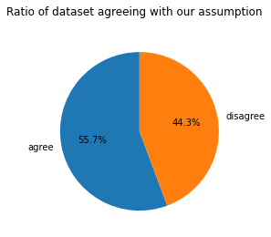

```python
#expected impact
exp_imp = []
for idx,row in dt.iterrows():
    val = 0
    # part 1 of assumption
    if row['expected_winning_record'] == 1 and row['inj_diff'] <= 0:
        val = 1
    #part 2 of assumption
    if row['expected_winning_record'] == 0 and row['inj_diff'] > 0:
        val = 1
    exp_imp.append(val)
dt['exp_imp'] = exp_imp


labels = ['agree','disagree']
sizes = [sum(exp_imp),len(exp_imp)-sum(exp_imp)]

pyplot.pie(sizes, labels=labels, autopct='%1.1f%%',startangle=90)
pyplot.suptitle("Ratio of dataset agreeing with our assumption")
pyplot.show()
```

From the pie chart we can see that our assumption is near even split with small majority to agreement.

Perhaps if we look at our assumption holds better if we are looking at the really good teams or bad teams. To test this out, we select teams with play-off appearance and test our assumption.

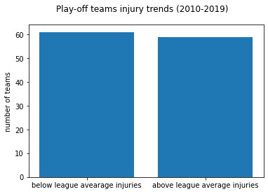

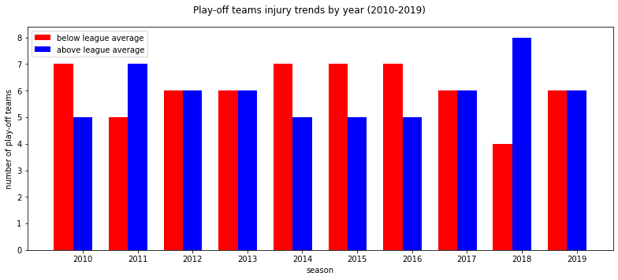

```python
#grouping by play-off appearance
playoff_suc = dt.groupby(['playoffs'])

playoff_teams = []
for teams in playoff_suc:
    if teams[0] == 1:
        playoff_teams = teams[1]
# counting play-off teams with below league average injuries
inj = [1 if row['inj_diff'] <= 0 else 0 for idx,row in playoff_teams.iterrows()]
pyplot.bar(['below league avearage injuries','above league average injuries'],[sum(inj),len(inj)-sum(inj)])
pyplot.suptitle("Play-off teams injury trends (2010-2019)")
pyplot.ylabel("number of teams")
pyplot.show()

# grouping playoff teams by year and counting teams injury record
playoff_suc_by_year = playoff_teams.groupby(['year'])
above_average = []
below_average = []
years = np.arange(10)
for year in playoff_suc_by_year:
    blw = 0
    abv = 0
    for idx,row in year[1].iterrows():
        if row['inj_diff'] <= 0:
            blw = blw + 1
        else:
            abv = abv + 1
    above_average.append(abv)
    below_average.append(blw)

# plotting a bar graph comparing the injury records of playoff teams by year
bar_width= .35
fig, ax = pyplot.subplots()
fig.set_size_inches(11, 5)
pyplot.bar(years,below_average,bar_width,color='r',label='below league average')
pyplot.bar(years+bar_width,above_average,bar_width,color='b',label='above league average')
pyplot.suptitle("Play-off teams injury trends by year (2010-2019)")
pyplot.xticks(years + bar_width, ('2010', '2011', '2012', '2013','2014','2015','2016','2017','2018','2019'))
pyplot.xlabel('season')
pyplot.ylabel('number of play-off teams')
pyplot.tight_layout()
pyplot.legend()
pyplot.show()
```

The first bar graph indicates that play-offs teams are near equal odds of being less or more injuried than the league average, but the second bar graph indicates that most years (8/10) there were more or equal number of play-off teams with injuries less than the league average.

Let's try this same process but on the teams with the bottom 5 winning percentage for each league year.

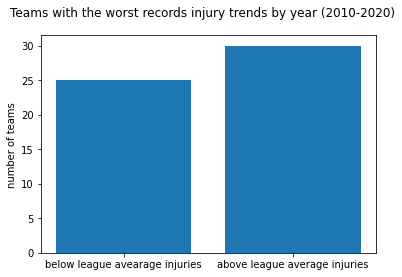

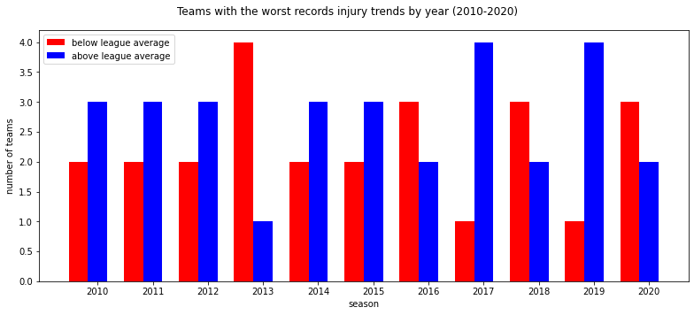

```python
#grouping data by year
teams_by_year = dt.groupby(['year'])

below_average = []
above_average = []

#sorting teams from each year by winning record and collecting the bottom 5.
for year in teams_by_year:
    cur = year[1].sort_values(by=['winning_percentage'])
    inj = []
    ct = 0
    for idx,row in cur.iterrows():
        if ct == 5:
            break
        if row['inj_diff'] > 0:
            inj.append(1)
        else:
            inj.append(0)
        ct = ct + 1
    above_average.append(sum(inj))
    below_average.append(len(inj)-sum(inj))

# making a bar graph of totals
a = sum(above_average)
b = sum(below_average)
pyplot.bar(['below league avearage injuries','above league average injuries'],[b,a])
pyplot.suptitle("Teams with the worst records injury trends by year (2010-2020)")
pyplot.ylabel("number of teams")
pyplot.show()


# making a bar graph for each year.
years= np.arange(11)
bar_width= .35
fig, ax = pyplot.subplots()
fig.set_size_inches(11, 5)
pyplot.bar(years,below_average,bar_width,color='r',label='below league average')
pyplot.bar(years+bar_width,above_average,bar_width,color='b',label='above league average')
pyplot.suptitle("Teams with the worst records injury trends by year (2010-2020)")
pyplot.xticks(years + bar_width, ('2010', '2011', '2012', '2013','2014','2015','2016','2017','2018','2019','2020'))
pyplot.xlabel('season')
pyplot.ylabel('number of teams')
pyplot.tight_layout()
pyplot.legend()
pyplot.show()
```

## what can we conclude

After visualizing our data we can see that ther edoes seem to exist a relationship between injury and a team's performance. Furthermore, it seems like injuries impact team performance negatively. But there are also teams that do not exhibit this relationship, infact 44% of datasets do not exhibit this relationship. So does that mean injury and team performance is just a correlation?

To answer that we need more data. We do not know why certain teams do not exhibit this relationship despite how reasonable our assumptions were. Maybe some teams have better player depth so the drop off in quality is not much. Maybe some teams have better spending habits so they don't sign injury prone players. Maybe some teams have young players that end up playing better than the starters. These and more reason could likely reason why some teams performed better the amount of injuries they endured. We simply need more data to make a better investigation. Data related to roster ranking, salary spending, and etc.. would help us get closer to our answer.

# Making predictions based on our data

Even though we do not as much features as we would wanted, we can try out some classifers.

### Model selection

We will fit a model on a teams using bunch of binary features, and they are winning_record? and expected_winning_record? (question mark indicates it a 1 = yes or 0 = no question), and also the injury record difference from the league average for each year.

We chose to use knn and decision tree as our initial classifiers and ran 10 fold cross validation to pick which model fit better with our data. After our tests knn had an accurary 98% so we chose to use knn to make some classifications to see if a team would be considered to be impacted by injuries.more details below...

```python
from sklearn.tree import DecisionTreeClassifier
from sklearn.neighbors import KNeighborsClassifier
from sklearn.metrics import accuracy_score
from sklearn.model_selection import KFold
import numpy as np


X = dt[['expected_winning_record','winning_record','inj_diff']]
y = dt[['exp_imp']]

def Decision_Tree_TenFoldCV():
    #shuffling and spliting dataset into 10 bins
    d = KFold(10,shuffle=True)
    score = []
    for train_index,test_index in d.split(X):
        # splitting dataset into training and testing batches
        tr_data_x = pd.DataFrame([ X.iloc[i] for i in train_index])
        te_data_x = pd.DataFrame([ X.iloc[i] for i in test_index])

        tr_data_y = pd.DataFrame([y.iloc[i] for i in train_index])
        te_data_y = pd.DataFrame([y.iloc[i] for i in test_index])

        # training the training dataset with a decision tree
        m = DecisionTreeClassifier(max_depth=4).fit(tr_data_x,tr_data_y)

        # making a predicton with testing dataset
        pr_data_y = m.predict(te_data_x)

        # scoring the accuracy of the prediction
        score.append(accuracy_score(pr_data_y,te_data_y))
    return np.asarray(score)

def knn_TenFoldCV():
    #shuffling and spliting dataset into 10 bins
    d = KFold(10,shuffle=True)
    score = []
    for train_index,test_index in d.split(X):
        # splitting dataset into training and testing batches
        tr_data_x = pd.DataFrame([ X.iloc[i] for i in train_index])
        te_data_x = pd.DataFrame([ X.iloc[i] for i in test_index])

        tr_data_y = pd.DataFrame([y.iloc[i] for i in train_index])
        te_data_y = pd.DataFrame([y.iloc[i] for i in test_index])

        # training the training dataset with knn
        m = KNeighborsClassifier(n_neighbors = 5).fit(tr_data_x,np.ravel(tr_data_y,order='C'))

        # making a predicton with testing dataset
        pr_data_y = m.predict(te_data_x)

        # scoring the accuracy of the prediction
        score.append(accuracy_score(pr_data_y,te_data_y))
    return np.asarray(score)

# reporting scores
knn = knn_TenFoldCV()
dec_t = Decision_Tree_TenFoldCV()
print(f"Average score for decision tree: {dec_t.mean()} std:{dec_t.std()} standard error: {dec_t.std()/np.sqrt(10)}")
print(f"Average score for knn: {knn.mean()} std:{knn.std()} standard error: {knn.std()/np.sqrt(10)}")
```

```
Average score for decision tree: 0.9200793650793653 std:0.10525021477294269 standard error: 0.03328304029044006
Average score for knn: 0.9829365079365079 std:0.026152569971224122 standard error: 0.008270168777599243
```

```python
# dropping datasets from 2020
d = dt.drop(dt[dt['year'] == 2020].index)

# getting training data from years 2010-2019
X = d[['expected_winning_record','winning_record','inj_diff']]
y = d[['exp_imp']]

#fitting a model
knn = KNeighborsClassifier(n_neighbors = 5).fit(X,np.ravel(y,order='C'))
```

## Making predictions based on 2020 data

below is a bar graph of the injury record of every team in 2020 in the NFL through out week 14. Using our model we are going to see if injuries have likely made an impact on their season.

For now we will choose 4 teams Dallas,Atlanta,Pittsburgh,and Kansas City see what our model says: Through week 14, Dallas has a record of 4-9 and an expected record of 4.3-8.7. Kansas City has a record of 12-1 and an expected record of 9.1-3.9. Atlanta has a record of 4-9 and an expected record of 6.6-6.4. Pittsburgh has a record of 11-2 an expected record of 9.3-3.7.

my predictions: Dallas: yes, Kansas city: yes, Atlanta: No, Pittsburgh: No,

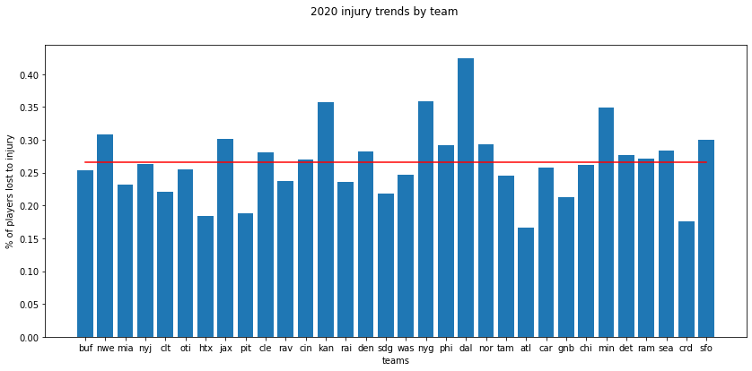

```python
data_by_year = dt.groupby(['year'])
injury_data_2020 = []

for year in data_by_year:
    if year[0] == 2020:
        injury_data_2020 = year[1]

#injury_data_2020
fig = pyplot.gcf()
fig.set_size_inches(14, 6)
pyplot.bar(injury_data_2020['team'],injury_data_2020['percent_of_players_lost_to_injury'])
pyplot.suptitle("2020 injury trends by team")
pyplot.xlabel('teams')
pyplot.ylabel('% of players lost to injury')
pyplot.plot(injury_data_2020['team'],injury_data_2020['league_average_percent_of_players_lost_to_injury'],'r')
pyplot.show()
```

```python
dal = knn.predict([[0,0,0.424107]])
kan = knn.predict([[1,1,0.357143]])
atl = knn.predict([[1,0,0.166667]])
pitt = knn.predict([[1,1,0.188776]])

dal,kan,atl,pitt
```

```
(array([1]), array([0]), array([0]), array([0]))
```

### model predictions:

Dallas: yes, Kansas city: No, Atlanta: No, Pittsburgh: No,

#### observations

As expected Dallas would be impacted as they have one of the worse record in football and also most injured according to our metric. Atlanta has a winning expected record indicating they play better than their record and our metric shows that they were the least injured. Pittsburgh has one of the best records in football, and our injury metric show them to be one of the least impacted teams.

Now Kansas city is really interesting, they have one of the best records and also are one of the most injured teams in the NFL, out model predicts that injuries have no impact despite having a lower expected record than there actaul record. So is KC really not impacted by injuries? is it because of their schedule they are performing better with alot of injuries, is it their player depth? Need more data to answer.